# EU/non-EU

Marina Vabistsevits

12/08/2020

```r
data_all<-read_csv("../data/tidy/food_hazards_data_all.csv")
```

## Exploring and tidying EU columns

```r
# this is the real EU list
european_union<-c("Austria", "Andorra", "Belgium", "Bulgaria", "Croatia", "Cyprus", "Czech Republic", "Denmark", "Estonia", "Finland", "France", "Germany", "Greece", "Hungary", "Ireland", "Italy", "Latvia", "Lithuania", "Luxembourg", "Malta", "Netherlands", "Poland", "Portugal", "Romania", "Slovakia", "Slovenia", "Spain", "Sweden")

##europe_not_eu <-c("Norway", "Switzerland", "Iceland", "Belarus", "Ukraine", "Serbia", "Albania",  "Kosovo" , "Montenegro"  )
#setdiff(european_union, data_all$origin_country)
```

```r
# correct EU columns with true EU/non-EU
data_corrected<-data_all %>%
  mutate(origin_country_EU= ifelse(origin_country %in% european_union, "EU", "non_EU")) %>%
  mutate(notified_country_EU= ifelse(notified_country %in% european_union, "EU", "non_EU"))

data_corrected<-data_corrected %>%
  mutate(origin_country_EU= ifelse(origin_country == "United Kingdom", "UK", origin_country_EU)) %>%
  mutate(notified_country_EU= ifelse(notified_country == "United Kingdom", "UK", notified_country_EU))
```

```r
data_corrected %>% count(origin_country_EU)
```

```
## # A tibble: 4 x 2
##   origin_country_EU     n
##   <chr>             <int>
## 1 EU                 9502
## 2 non_EU            19944
## 3 UK                 1966
## 4 <NA>                692
```

```r
data_corrected %>% count(notified_country_EU)
```

```
## # A tibble: 3 x 2
##   notified_country_EU     n
##   <chr>               <int>
## 1 EU                  14337
## 2 non_EU              15015
## 3 UK                   2752
```

```r
data_corrected %>% filter(origin_country_EU == "EU") %>% pull(origin_country) %>% unique() %>% sort()
```

```
##  [1] "Andorra"        "Austria"        "Belgium"        "Bulgaria"
##  [5] "Croatia"        "Cyprus"         "Czech Republic" "Denmark"
##  [9] "Estonia"        "Finland"        "France"         "Germany"
## [13] "Greece"         "Hungary"        "Ireland"        "Italy"
## [17] "Latvia"         "Lithuania"      "Luxembourg"     "Malta"
## [21] "Netherlands"    "Poland"         "Portugal"       "Romania"
## [25] "Slovakia"       "Slovenia"       "Spain"          "Sweden"
```

```r
data_corrected %>% filter(notified_country_EU == "EU") %>% pull(notified_country) %>% unique() %>% sort()
```

```
##  [1] "Austria"        "Belgium"        "Bulgaria"       "Croatia"
##  [5] "Cyprus"         "Czech Republic" "Denmark"        "Estonia"
##  [9] "Finland"        "France"         "Germany"        "Greece"
## [13] "Hungary"        "Ireland"        "Italy"          "Latvia"
## [17] "Lithuania"      "Luxembourg"     "Malta"          "Netherlands"
## [21] "Poland"         "Portugal"       "Romania"        "Slovakia"
## [25] "Slovenia"       "Spain"          "Sweden"
```

```r
data_corrected %>% filter(origin_country_EU != "EU") %>% pull(origin_country) %>% unique() %>% sort()
```

```
##   [1] "Afghanistan"                 "Albania"
##   [3] "Algeria"                     "Angola"
##   [5] "Argentina"                   "Australia"
##   [7] "Azerbaijan"                  "Bangladesh"
##   [9] "Barbados"                    "Belarus"
##  [11] "Belize"                      "Benin"
##  [13] "Bolivia"                     "Bosnia and Herzegovina"
##  [15] "Brazil"                      "Brunei"
##  [17] "Burkina Faso"                "Cambodia"
##  [19] "Cameroon"                    "Canada"
##  [21] "Cape Verde"                  "Chad"
##  [23] "Chile"                       "China"
##  [25] "Colombia"                    "Costa Rica"
##  [27] "Cuba"                        "Dominican Republic"
##  [29] "Ecuador"                     "Egypt"
```

[output cut: 45 more lines]

```r
data_corrected %>% filter(notified_country_EU != "EU") %>% pull(notified_country) %>% unique() %>% sort()
```

```
##  [1] "Argentina"                "Australia"
##  [3] "Canada"                   "Hong Kong S.A.R."
##  [5] "Iceland"                  "Israel"
##  [7] "Japan"                    "New Zealand"
##  [9] "Nigeria"                  "Norway"
## [11] "Switzerland"              "United Kingdom"
## [13] "United States of America"
```

```r
# reports per country from EU countries
data_corrected %>% filter(origin_country_EU == "EU") %>% count(origin_country, sort = T)
```

```
## # A tibble: 28 x 2
##    origin_country     n
##    <chr>          <int>
##  1 France          1823
##  2 Italy           1130
##  3 Belgium         1017
##  4 Poland           885
##  5 Netherlands      840
##  6 Germany          811
##  7 Spain            777
##  8 Denmark          492
##  9 Hungary          223
## 10 Slovakia         183
## # … with 18 more rows
```

```r
# reports per country from non-EU countries
data_corrected %>% filter(origin_country_EU != "EU") %>% count(origin_country, sort = T)
```

```
## # A tibble: 120 x 2
##    origin_country               n
##    <chr>                    <int>
##  1 Canada                    6508
##  2 United States of America  4763
##  3 United Kingdom            1966
##  4 China                     1040
##  5 Turkey                     826
##  6 Brazil                     676
##  7 India                      623
##  8 Vietnam                    450
##  9 Thailand                   426
## 10 Australia                  402
## # … with 110 more rows
```

### reports sources

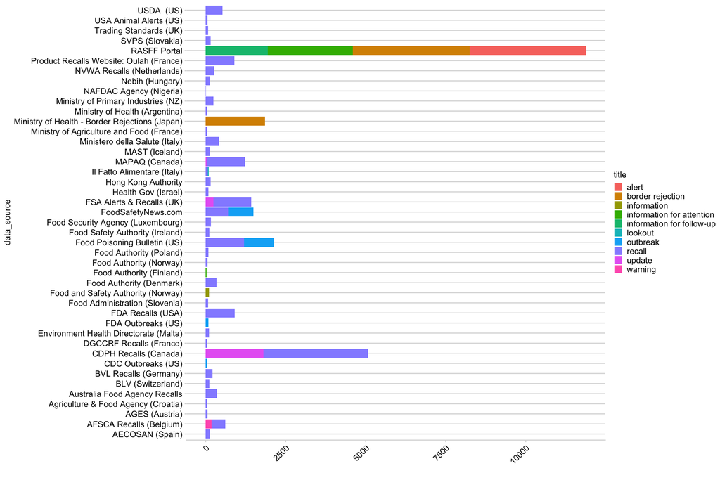

```r
ggplot(data_corrected, aes(x = data_source, fill = alert_type)) +
  geom_bar()+
  theme_minimal_hgrid(10, rel_small = 1)+
  coord_flip()+
  labs(fill = "title", y="") +
  theme(axis.text.x = element_text(angle = 45, hjust = 1))
```

### reports sources

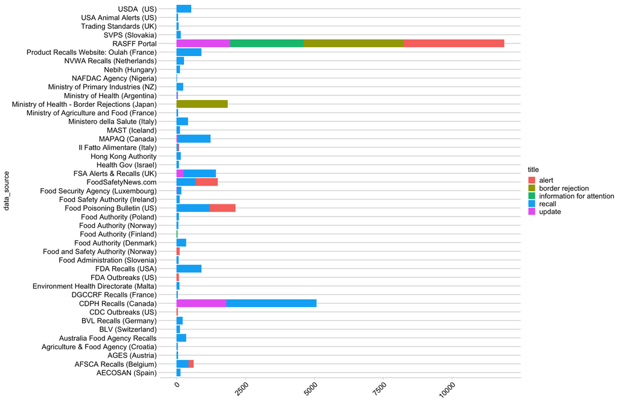

```r
ggplot(data_corrected, aes(x = data_source, fill = alert_type_large)) +
  geom_bar()+
  theme_minimal_hgrid(10, rel_small = 1)+
  coord_flip()+
  labs(fill = "title", y="") +
  theme(axis.text.x = element_text(angle = 45, hjust = 1))
```

### RASFF - Food and Feed Safety Alerts

The EU has one of the highest food safety standards in the world – largely thanks to the solid set of EU legislation in place, which ensures that food is safe for consumers. A key tool to ensure the flow of information to enabling swift reaction when risks to public health are detected in the food chain is RASFF – the Rapid Alert System for Food and Feed. Created in 1979, RASFF enables information to be shared efficiently between its members (EU Member State national food safety authorities, Commission, EFSA, ESA, Norway, Liechtenstein, Iceland and Switzerland) and provides a round-the-clock service to ensure that urgent notifications are sent, received and responded to collectively and efficiently. Thanks to RASFF, many food safety risks had been averted before they could have been harmful to European consumers. Vital information exchanged through RASFF can lead to products being recalled from the market. A robust system, which has matured over the years, RASFF continues to show its value to ensure food safety in the EU and beyond.

https://ec.europa.eu/food/safety/rasff_en

https://ec.europa.eu/food/sites/food/files/safety/docs/rasff_annual_report_2018.pdf

https://ec.europa.eu/food/sites/food/files/safety/docs/rasff_annual_report_2018_infograph.pdf

In 2018, 42% of RASFF notifications concerned controls at the outer EEA borders(6 ) at points of entry or border posts. When the consignment was not accepted for import (“border control – consignment detained”) a border rejection notification was made. In some cases, a sample was taken for analysis at the border yet the consignment was not held there but was forwarded to its destination under customs’ seals (“border control – consignment under customs”). This means that it should remain stored there until the result of the analysis is available.

https://ec.europa.eu/food/sites/food/files/safety/docs/rasff_country-fact-sheet_2018_gbr.pdf

RASFF accounts for 37% of all alerts in the provided dataset

About UK/EU food trade:

https://ec.europa.eu/info/food-farming-fisheries/farming/eu-agriculture-and-brexit_en

```r
# split the data source names into "name" and "country"
# RAFSS country will be "EU"

data_corrected %>% count(data_source, sort=T)
```

```
## # A tibble: 43 x 2
##    data_source                                        n
##    <chr>                                          <int>
##  1 RASFF Portal                                   11892
##  2 CDPH Recalls (Canada)                           5075
##  3 Food Poisoning Bulletin (US)                    2132
##  4 Ministry of Health - Border Rejections (Japan)  1850
##  5 FoodSafetyNews.com                              1494
##  6 FSA Alerts & Recalls (UK)                       1427
##  7 MAPAQ (Canada)                                  1230
##  8 FDA Recalls (USA)                                904
##  9 Product Recalls Website: Oulah (France)          896
## 10 AFSCA Recalls (Belgium)                          614
## # … with 33 more rows
```

```r
data_corrected <- data_corrected %>%
  extract(data_source, into = c("data_source_name", "data_source_country"), "([^(]+)\\s+\\((.*).", remove =F) %>%
  mutate(data_source_country = ifelse(grepl("Hong Kong", data_source), "Hong Kong", data_source_country),
         data_source_name = ifelse(grepl("Hong Kong", data_source), data_source, data_source_name)) %>%
  mutate(data_source_country = ifelse(grepl("Australia", data_source), "Australia", data_source_country),
         data_source_name = ifelse(grepl("Australia", data_source), data_source, data_source_name)) %>%
  mutate(data_source_country = ifelse(grepl("RASFF", data_source), "EU", data_source_country),
         data_source_name = ifelse(grepl("RASFF", data_source), data_source, data_source_name)) %>%
  mutate(data_source_country = ifelse(data_source_country == "US", "USA", data_source_country)) %>%
  mutate(data_source_country = ifelse(grepl("FoodSafetyNews.com", data_source), "USA", data_source_country),
         data_source_name = ifelse(grepl("FoodSafetyNews.com", data_source), data_source, data_source_name))


# alerts by country and source name
data_corrected %>% count(data_source_country, sort=T)
```

```
## # A tibble: 31 x 2
##    data_source_country     n
##    <chr>               <int>
##  1 EU                  11892
##  2 Canada               6305
##  3 USA                  5242
##  4 Japan                1850
##  5 UK                   1504
##  6 France                995
##  7 Belgium               614
##  8 Italy                 511
##  9 Australia             345
## 10 Denmark               342
## # … with 21 more rows
```

```r
data_corrected %>% count(data_source_name, sort=T)
```

```
## # A tibble: 40 x 2
##    data_source_name                           n
##    <chr>                                  <int>
##  1 RASFF Portal                           11892
##  2 CDPH Recalls                            5075
##  3 Food Poisoning Bulletin                 2132
##  4 Ministry of Health - Border Rejections  1850
##  5 FoodSafetyNews.com                      1494
##  6 FSA Alerts & Recalls                    1427
##  7 MAPAQ                                   1230
##  8 FDA Recalls                              904
##  9 Product Recalls Website: Oulah           896
## 10 AFSCA Recalls                            614
## # … with 30 more rows
```

```r
data_corrected %>% write_csv("../data/tidy/food_hazards_data_all.csv")
```

```r
# count how many per country

data_tmp <- read_csv("../data/tidy/food_hazards_data_all.csv")

count_per_origin<-
  data_tmp %>% filter(notified_country_EU =="UK") %>%
            count(origin_country, sort=T) %>%
            rename('alerts_from_origin'='n')


data_tmp<- data_tmp %>%
  filter(notified_country_EU =="UK") %>% left_join(., count_per_origin, by = "origin_country")

data_tmp %>% write_csv("../data/tidy/food_hazards_data_UK_notified_tmp.csv")
```

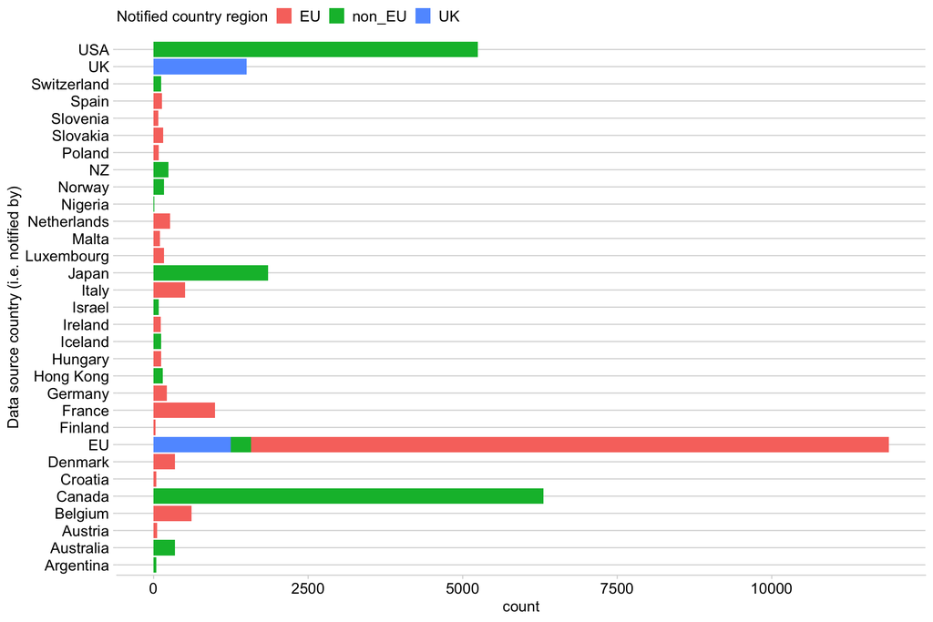

```r
ggplot(data_corrected, aes(x = data_source_country,  fill = notified_country_EU)) +
  geom_bar()+
  theme_minimal_hgrid(14, rel_small = 1)+
  coord_flip()+
  labs(fill = "Notified country region", x="Data source country (i.e. notified by)") +
  theme(legend.position = "top" )
```

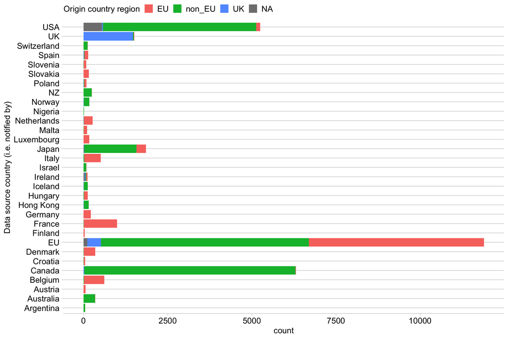

```r
ggplot(data_corrected, aes(x = data_source_country,  fill = origin_country_EU)) +
  geom_bar()+
  theme_minimal_hgrid(14, rel_small = 1)+
  coord_flip()+
  labs(fill = "Origin country region", x="Data source country (i.e. notified by)") +
  theme(legend.position = "top" )
```

```r
# EU countries reported most hazards in:
data_corrected %>% filter(data_source_country == "EU") %>% count(origin_country, sort=T)
```

```
## # A tibble: 143 x 2
##    origin_country     n
##    <chr>          <int>
##  1 Poland           802
##  2 Turkey           777
##  3 France           683
##  4 Brazil           639
##  5 Spain            627
##  6 China            596
##  7 Netherlands      565
##  8 India            561
##  9 Germany          549
## 10 Italy            532
## # … with 133 more rows
```

```r
# UK reported most hazards in:
data_corrected %>% filter(data_source_country == "UK") %>% count(origin_country, sort=T)
```

```
## # A tibble: 12 x 2
##    origin_country               n
##    <chr>                    <int>
##  1 United Kingdom            1462
##  2 Iceland                     15
##  3 Ireland                     10
##  4 Ethiopia                     3
##  5 Cyprus                       2
##  6 France                       2
##  7 India                        2
##  8 Netherlands                  2
##  9 Turkey                       2
## 10 United States of America     2
## 11 Canada                       1
## 12 China                        1
```

## UK may lose accees to RAFSS alerts after Brexit

The current food safety regulatory regime relies on a number of systems administered at present at an EU level. The FSA has recognised that some plans have sufficiently long lead times that the FSA needs to begin now for them to remain viable, even though we hope not to need all these provisions in a deal with the EU. Many of the plans have been carefully developed to provide the flexibility to respond to a wide range of negotiated outcomes. The FSA is working to ensure that, to the extent that our plans rely on alternative provision, the cost and necessary lead-in is allowed for.

https://www.foodsafetynews.com/2019/03/food-safety-issues-up-in-the-air-as-u-k-approaches-brexit-u-s-food-targeted/

The United Kingdom will lose access to RASFF after Brexit and Britain’s future relationship with EFSA remains unclear, according to the British public health minister. Britain’s future trade with U.S. food companies is also a question mark, with some in the U.K. saying certain food safety practices in the United States are unacceptable. Questioned by the British Parliament’s Energy and Environment Committee this week, Minister Steve Brine, MP, confirmed the U.K. would not be able to vote in the Standing Committee on Plants, Animals, Food and Feed or have access to the Rapid Alert System for Food and Feed (RASFF) after the U.K.’s exit from the European Union later this month. The planned departure is also known as Brexit. Brine admitted it is not known what the U.K.’s relationship with the European Food Safety Authority (EFSA) will be, and whether Britain will retain access to food safety risk assessment work.

https://www.foodnavigator.com/Article/2018/05/31/UK-must-have-access-to-RASFF-and-TRACES-after-leaving-EU-LGA

https://www.foodsafetynews.com/2020/01/coming-in-2020-europe-and-asia/

*Food safety, trade deals and Brexit* The United Kingdom is still scheduled to leave the European Union following results of a referendum in 2016 and despite delays in 2019 this is almost certain to happen in early 2020. The U.K. and Europe have an agreement in place until the end of this year to keep things as they are now. The plan is to strike a trade deal between the two parties by the end of 2020. British Prime Minister Boris Johnson has said this transition period will not be extended. The government has repeated many times that food safety and standards will not be compromised but that has not made the concerns go away. International trade negotiations with the U.S., Australia, New Zealand and Japan are on the table. The issue was emphasized in a New Year’s message from National Farmers Union president, Minette Batters. She said the country cannot allow food imports such as chlorinated chicken and hormone-fed beef that are produced in ways illegal in the U.K., onto the U.K.’s supermarket shelves.

http://brexitdb.com/db?tag=1341&sort=created&order=desc

https://inews.co.uk/news/brexit/eu-regulations-poll-best-for-britain-environment-food-jobs-402115

https://www.thelancet.com/journals/lancet/article/PIIS0140-6736(19)30540-9/fulltext

```r
# RAFSS reported hazards per region
data_corrected %>% filter(data_source_name == "RASFF Portal") %>%
                   count(notified_country_EU)
```

```
## # A tibble: 3 x 2
##   notified_country_EU     n
##   <chr>               <int>
## 1 EU                  10313
## 2 non_EU                331
## 3 UK                   1248
```

```r
# what are those non-EU countries?
data_corrected %>%
  filter(data_source_name == "RASFF Portal") %>%
  filter(notified_country_EU =="non_EU") %>%
  count(notified_country, sort=T)
```

```
## # A tibble: 3 x 2
##   notified_country     n
##   <chr>            <int>
## 1 Norway             168
## 2 Switzerland        158
## 3 Iceland              5
```

```r
# EU countries notify about hazards by own sources (not RAFSS)
data_corrected %>% filter(data_source_name != "RASFF Portal") %>%
                   count(notified_country_EU)
```

```
## # A tibble: 3 x 2
##   notified_country_EU     n
##   <chr>               <int>
## 1 EU                   4024
## 2 non_EU              14684
## 3 UK                   1504
```

```r
#let's see notification from EU countries that came not from RAFSS
data_corrected %>%
  filter(data_source_name != "RASFF Portal") %>%
  filter(notified_country_EU == "EU") %>%
  count(notified_country, origin_country, sort=T)
```

```
## # A tibble: 127 x 3
##    notified_country origin_country     n
##    <chr>            <chr>          <int>
##  1 France           France           984
##  2 Belgium          Belgium          592
##  3 Italy            Italy            489
##  4 Denmark          Denmark          340
##  5 Netherlands      Netherlands      257
##  6 Germany          Germany          214
##  7 Luxembourg       Luxembourg       160
##  8 Slovakia         Slovakia         153
##  9 Hungary          Hungary          108
## 10 Malta            Malta            102
## # … with 117 more rows
```

```r
# th majority of them are internal
```

```r
# UK -own food hazard sources
# NB only in recent years
data_corrected %>% filter(data_source_name != "RASFF Portal") %>%
                   filter(notified_country_EU == "UK") %>%
                   count(data_source , date_published_year, sort=T) %>%
                   arrange(data_source)
```

```
## # A tibble: 5 x 3
##   data_source               date_published_year     n
##   <chr>                                   <dbl> <int>
## 1 FSA Alerts & Recalls (UK)                2019   696
## 2 FSA Alerts & Recalls (UK)                2018   568
## 3 FSA Alerts & Recalls (UK)                2020   163
## 4 Trading Standards (UK)                   2020    52
## 5 Trading Standards (UK)                   2019    25
```

```r
# UK-own data sources mostly report internal product recalls

# FSA itself
data_corrected %>% filter(data_source_name != "RASFF Portal") %>%
                   filter(notified_country_EU == "UK") %>%
                   filter(data_source == "FSA Alerts & Recalls (UK)") %>%
                   count(origin_country, alert_type, sort=T)
```

```
## # A tibble: 12 x 3
##    origin_country           alert_type     n
##    <chr>                    <chr>      <int>
##  1 United Kingdom           recall      1145
##  2 United Kingdom           update       244
##  3 Iceland                  recall        13
##  4 Ireland                  recall        10
##  5 Ethiopia                 recall         3
##  6 Cyprus                   recall         2
##  7 India                    recall         2
##  8 Netherlands              recall         2
##  9 Turkey                   recall         2
## 10 United States of America recall         2
## 11 Canada                   recall         1
## 12 France                   recall         1
```

```r
# Trading Standards (UK)
data_corrected %>% filter(data_source_name != "RASFF Portal") %>%
                   filter(notified_country_EU == "UK") %>%
                   filter(data_source == "Trading Standards (UK)") %>%
                   count(origin_country, alert_type, sort=T)
```

```
## # A tibble: 4 x 3
##   origin_country alert_type     n
##   <chr>          <chr>      <int>
## 1 United Kingdom recall        73
## 2 Iceland        recall         2
## 3 China          recall         1
## 4 France         recall         1
```

```r
# FSA and TS UK alerts %
data_corrected %>% filter(notified_country_EU == "UK") %>%
                   filter(data_source %in% c("Trading Standards (UK)", "FSA Alerts & Recalls (UK)")) %>%
                   count(origin_country,  sort=T)
```

```
## # A tibble: 12 x 2
##    origin_country               n
##    <chr>                    <int>
##  1 United Kingdom            1462
##  2 Iceland                     15
##  3 Ireland                     10
##  4 Ethiopia                     3
##  5 Cyprus                       2
##  6 France                       2
##  7 India                        2
##  8 Netherlands                  2
##  9 Turkey                       2
## 10 United States of America     2
## 11 Canada                       1
## 12 China                        1
```

```r
                  #filter(origin_country != "United Kingdom") %>% pull(n) %>% sum()


#1462/(1462+42)
```

```r
# UK notifications within RAFSS include a variety of things outside the UK

# notified by the UK; grouped by alert type +  by country of origin
data_corrected %>% filter(data_source_name == "RASFF Portal") %>%
                   filter(notified_country_EU == "UK") %>%
                   count(origin_country, alert_type, sort=T)
```

```
## # A tibble: 156 x 3
##    origin_country alert_type                    n
##    <chr>          <chr>                     <int>
##  1 India          border rejection            175
##  2 United Kingdom alert                       111
##  3 Brazil         border rejection             89
##  4 United Kingdom information for attention    66
##  5 Ghana          border rejection             62
##  6 China          border rejection             61
##  7 Nigeria        border rejection             58
##  8 Thailand       border rejection             38
##  9 China          information for attention    32
## 10 Turkey         border rejection             31
## # … with 146 more rows
```

```r
#notified by the UK; just by country of origin
data_corrected %>% filter(data_source_name == "RASFF Portal") %>%
                   filter(notified_country_EU == "UK") %>%
                   count(origin_country, sort=T)
```

```
## # A tibble: 82 x 2
##    origin_country               n
##    <chr>                    <int>
##  1 United Kingdom             199
##  2 India                      196
##  3 China                      102
##  4 Brazil                      95
##  5 Ghana                       63
##  6 Nigeria                     60
##  7 Turkey                      55
##  8 United States of America    53
##  9 Thailand                    49
## 10 Laos                        22
## # … with 72 more rows
```

```r
# UK seems to be a big entry point point for non-EU products/hazards into EU
data_corrected %>% filter(data_source_name == "RASFF Portal") %>%
                   filter(notified_country_EU == "UK") %>%
                   count(origin_country_EU, sort=T)
```

```
## # A tibble: 4 x 2
##   origin_country_EU     n
##   <chr>             <int>
## 1 non_EU              930
## 2 UK                  199
## 3 EU                  102
## 4 <NA>                 17
```

```r
# these countries with RAFSS notify about hazards from UK
data_corrected %>% filter(data_source_name == "RASFF Portal") %>%
                   filter(origin_country_EU == "UK") %>%
                   count(notified_country, sort=T)
```

```
## # A tibble: 27 x 2
##    notified_country     n
##    <chr>            <int>
##  1 United Kingdom     199
##  2 Ireland             24
##  3 Italy               24
##  4 Sweden              23
##  5 Netherlands         22
##  6 Germany             21
##  7 France              17
##  8 Spain               12
##  9 Denmark             11
## 10 Poland               9
## # … with 17 more rows
```

```r
# these organisations (not RAFSS) report hazards from the UK
data_corrected %>% filter(data_source_name != "RASFF Portal") %>%
                   filter(origin_country_EU == "UK") %>%
                   count(data_source, sort=T)
```

```
## # A tibble: 14 x 2
##    data_source                                        n
##    <chr>                                          <int>
##  1 FSA Alerts & Recalls (UK)                       1389
##  2 Trading Standards (UK)                            73
##  3 Food Safety Authority (Ireland)                   25
##  4 FoodSafetyNews.com                                23
##  5 CDPH Recalls (Canada)                             14
##  6 AECOSAN (Spain)                                   10
##  7 Ministry of Health - Border Rejections (Japan)     8
##  8 USDA  (US)                                         5
##  9 Food Poisoning Bulletin (US)                       4
## 10 Hong Kong Authority                                2
## 11 MAST (Iceland)                                     2
## 12 Food Authority (Norway)                            1
## 13 Food Authority (Poland)                            1
## 14 NVWA Recalls (Netherlands)                         1
```

```r
# how many EU and non-EU harards are identified in the UK by different alert systems
data_corrected %>% filter(notified_country_EU =="UK") %>%
                  filter(origin_country_EU %in% c("non_EU", "EU")) %>%
                   count(data_source,  sort=T)
```

```
## # A tibble: 3 x 2
##   data_source                   n
##   <chr>                     <int>
## 1 RASFF Portal               1032
## 2 FSA Alerts & Recalls (UK)    38
## 3 Trading Standards (UK)        4
```

```r
#1032/(1032+4+38) # 96% RASFF
```

```r
# what product categories get most alrt by non-RAFSS
data_corrected %>% filter(data_source_name != "RASFF Portal") %>%
  count(product_categoty, sort=T)
```

```
## # A tibble: 33 x 2
##    product_categoty                                 n
##    <chr>                                        <int>
##  1 fruits and vegetables                         3211
##  2 meat and meat products (other than poultry)   3049
##  3 <NA>                                          2989
##  4 cereals and bakery products                   1692
##  5 milk and milk products                        1245
##  6 poultry meat and poultry meat products        1205
##  7 fish and fish products                        1119
##  8 nuts; nut products and seeds                   868
##  9 cocoa and cocoa preparations; coffee and tea   634
## 10 prepared dishes and snacks                     575
## # … with 23 more rows
```

```r
# by country
data_corrected %>% filter(data_source_name != "RASFF Portal") %>%
  count(product_categoty, origin_country,  sort=T)
```

```
## # A tibble: 933 x 3
##    product_categoty                            origin_country               n
##    <chr>                                       <chr>                    <int>
##  1 meat and meat products (other than poultry) Canada                    1521
##  2 fruits and vegetables                       Canada                     896
##  3 <NA>                                        Canada                     867
##  4 meat and meat products (other than poultry) United States of America   688
##  5 fruits and vegetables                       United States of America   640
##  6 cereals and bakery products                 Canada                     618
##  7 <NA>                                        United States of America   604
##  8 fish and fish products                      Canada                     460
##  9 poultry meat and poultry meat products      Canada                     433
## 10 poultry meat and poultry meat products      United States of America   370
## # … with 923 more rows
```

```r
# without canada, US, UK
data_corrected %>% filter(data_source_name != "RASFF Portal") %>%
  count(product_categoty, origin_country,  sort=T) %>%
  filter(!origin_country %in% c("Canada", "United States of America", "United Kingdom"))
```

```
## # A tibble: 852 x 3
##    product_categoty                            origin_country     n
##    <chr>                                       <chr>          <int>
##  1 milk and milk products                      France           204
##  2 fruits and vegetables                       France           147
##  3 <NA>                                        France           139
##  4 fruits and vegetables                       China            131
##  5 meat and meat products (other than poultry) France           117
##  6 fruits and vegetables                       Belgium          114
##  7 <NA>                                        Italy            109
##  8 <NA>                                        Slovakia         107
##  9 <NA>                                        Luxembourg        99
## 10 <NA>                                        China             98
## # … with 842 more rows
```

```r
# without EU countries
data_corrected %>% filter(data_source_name != "RASFF Portal") %>%
  filter(origin_country_EU != "EU") %>%
  count(product_categoty, origin_country,  sort=T) %>%
  filter(!origin_country %in% c("Canada", "United States of America", "United Kingdom"))
```

```
## # A tibble: 483 x 3
##    product_categoty                            origin_country     n
##    <chr>                                       <chr>          <int>
##  1 fruits and vegetables                       China            131
##  2 <NA>                                        China             98
##  3 crustaceans and products thereof            Vietnam           68
##  4 cereals and bakery products                 Australia         65
##  5 fish and fish products                      Vietnam           57
##  6 cereals and bakery products                 New Zealand       54
##  7 fruits and vegetables                       Australia         54
##  8 <NA>                                        Australia         47
##  9 meat and meat products (other than poultry) New Zealand       46
## 10 <NA>                                        Norway            46
## # … with 473 more rows
```

```r
data_corrected %>% filter(data_source_name != "RASFF Portal") %>%
  filter(origin_country_EU != "EU") %>%
  #filter(!origin_country %in% c("Canada", "United States of America", "United Kingdom")) %>%
  count(product_categoty, sort=T)
```

```
## # A tibble: 32 x 2
##    product_categoty                                 n
##    <chr>                                        <int>
##  1 meat and meat products (other than poultry)   2526
##  2 fruits and vegetables                         2503
##  3 <NA>                                          2161
##  4 cereals and bakery products                   1369
##  5 poultry meat and poultry meat products         958
##  6 fish and fish products                         896
##  7 milk and milk products                         752
##  8 nuts; nut products and seeds                   569
##  9 prepared dishes and snacks                     486
## 10 cocoa and cocoa preparations; coffee and tea   460
## # … with 22 more rows
```

## Let’s see what it’s like for Norway

```r
data_corrected %>% filter(notified_country == "Norway") %>%
                   count(data_source_country, sort=T)
```

```
## # A tibble: 2 x 2
##   data_source_country     n
##   <chr>               <int>
## 1 Norway                169
## 2 EU                    168
```

```r
data_corrected %>% filter(notified_country == "Norway") %>%
                   filter(data_source_country== "Norway") %>%
                   count(origin_country, sort=T)
```

```
## # A tibble: 12 x 2
##    origin_country               n
##    <chr>                    <int>
##  1 Norway                     153
##  2 United States of America     3
##  3 China                        2
##  4 Lesotho                      2
##  5 Vietnam                      2
##  6 Australia                    1
##  7 Chile                        1
##  8 Italy                        1
##  9 Laos                         1
## 10 Nigeria                      1
## 11 Spain                        1
## 12 United Kingdom               1
```

```r
data_corrected %>% filter(notified_country == "Norway") %>%
                   filter(data_source_country== "EU") %>%
                   count(origin_country, sort=T)
```

```
## # A tibble: 36 x 2
##    origin_country               n
##    <chr>                    <int>
##  1 United States of America    25
##  2 Thailand                    14
##  3 China                       12
##  4 Turkey                      11
##  5 India                       10
##  6 Sweden                       8
##  7 Laos                         7
##  8 Norway                       7
##  9 Argentina                    6
## 10 Italy                        6
## # … with 26 more rows
```

## Let’s see what it’s like for Switzerland

```r
data_corrected %>% filter(notified_country == "Switzerland") %>%
                   count(data_source_country, sort=T)
```

```
## # A tibble: 2 x 2
##   data_source_country     n
##   <chr>               <int>
## 1 EU                    158
## 2 Switzerland           119
```

```r
data_corrected %>% filter(notified_country == "Switzerland") %>%
                   filter(data_source_country== "Switzerland") %>%
                   count(origin_country, sort=T)
```

```
## # A tibble: 5 x 2
##   origin_country               n
##   <chr>                    <int>
## 1 Switzerland                113
## 2 France                       3
## 3 Australia                    1
## 4 United States of America     1
## 5 Vietnam                      1
```

```r
data_corrected %>% filter(notified_country == "Switzerland") %>%
                   filter(data_source_country== "EU") %>%
                   count(origin_country, sort=T)
```

```
## # A tibble: 35 x 2
##    origin_country               n
##    <chr>                    <int>
##  1 Turkey                      13
##  2 Thailand                    11
##  3 Vietnam                     11
##  4 Italy                       10
##  5 Switzerland                 10
##  6 Germany                      9
##  7 Netherlands                  9
##  8 France                       8
##  9 India                        8
## 10 United States of America     8
## # … with 25 more rows
```

Something else

```r
data_corrected %>%
  filter(food_feed_fcm == "food") %>%
  count(product_categoty, sort=T)
```

```
## # A tibble: 31 x 2
##    product_categoty                                      n
##    <chr>                                             <int>
##  1 fruits and vegetables                              5290
##  2 meat and meat products (other than poultry)        3999
##  3 <NA>                                               2966
##  4 poultry meat and poultry meat products             2518
##  5 fish and fish products                             2312
##  6 cereals and bakery products                        2146
##  7 nuts; nut products and seeds                       1936
##  8 milk and milk products                             1611
##  9 dietetic foods; food supplements; fortified foods  1379
## 10 herbs and spices                                   1021
## # … with 21 more rows
```

```r
data_corrected %>%
  filter(food_feed_fcm == "food") %>%
  filter(is.na(product_categoty)) %>%
  count(product, sort=T)
```

```
## # A tibble: 558 x 2
##    product            n
##    <chr>          <int>
##  1 <NA>            1813
##  2 bakery product    83
##  3 food              61
##  4 beef              27
##  5 product           25
##  6 pork              22
##  7 shell             22
##  8 meat product      18
##  9 sugar             15
## 10 sweetcorn         12
## # … with 548 more rows
```

```r
data_corrected %>%
  filter(food_feed_fcm == "food") %>%
  filter(data_source_country =="UK") %>%
  count(product_categoty, sort=T)
```

```
## # A tibble: 23 x 2
##    product_categoty                                 n
##    <chr>                                        <int>
##  1 fruits and vegetables                          292
##  2 cereals and bakery products                    200
##  3 <NA>                                           155
##  4 meat and meat products (other than poultry)    112
##  5 poultry meat and poultry meat products          89
##  6 other food product / mixed                      85
##  7 milk and milk products                          82
##  8 herbs and spices                                79
##  9 nuts; nut products and seeds                    68
## 10 cocoa and cocoa preparations; coffee and tea    62
## # … with 13 more rows
```

```r
data_corrected %>%
  filter(food_feed_fcm == "food") %>%
  filter(data_source_country =="EU") %>%
  count(product_categoty, sort=T)
```

```
## # A tibble: 30 x 2
##    product_categoty                                      n
##    <chr>                                             <int>
##  1 fruits and vegetables                              2079
##  2 poultry meat and poultry meat products             1313
##  3 fish and fish products                             1193
##  4 nuts; nut products and seeds                       1068
##  5 dietetic foods; food supplements; fortified foods  1033
##  6 meat and meat products (other than poultry)         950
##  7 herbs and spices                                    462
##  8 cereals and bakery products                         454
##  9 bivalve molluscs and products thereof               368
## 10 milk and milk products                              366
## # … with 20 more rows
```